# STATS 32: Introduction to R for Undergraduates

Elena Tuzhilina

Oct 12, 2021  
http://web.stanford.edu/~elenatuz/courses/stats32-aut2021/

# Recap of week 3

- Transforming data with `dplyr`
  - `select()`
  - `mutate()`
  - `arrange()`
  - `filter()`
  - `summarize()`
  - `group_by()`
- More data transformation with `tidyr`
  - `gather()`
- Review of function syntax

# Function syntax

The most important syntax in R is the **function call**. All R syntax has function calls underlying it.

A function call consists of:

- Function name
- Parentheses, and
- A list of arguments within the parentheses

```r
function_name(<inputs to the function>,
              <arguments which change
              how the function operates>)
```

# Function example

```r
function_name(<inputs to the function>,
              <arguments which change
              how the function operates>)
```

```r
x <- c(-5, -3, -1, 1, 3, NA)
mean(x)
```

```
## [1] NA
```

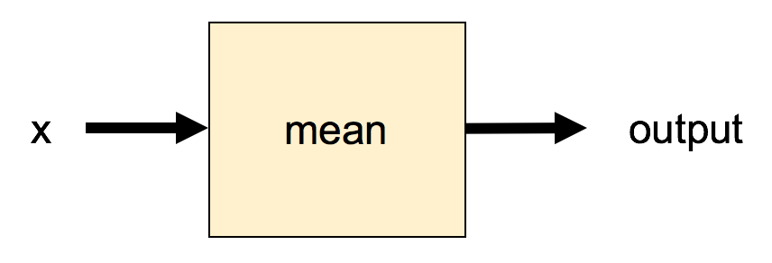

# Function example

```r
function_name(<inputs to the function>,
              <arguments which change
              how the function operates>)
```

```r
x <- c(-5, -3, -1, 1, 3, NA)
mean(x, na.rm = TRUE)
```

```
## [1] -1
```

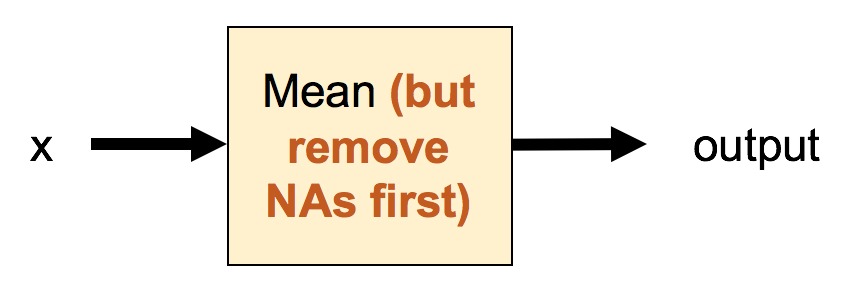

# `%>%` syntax with `dplyr`

Take the `mtcars` dataset, select just the `wt` and `mpg` columns, *then select rows with mpg < 15*

```r
mtcars %>%
    select(wt, mpg) %>%
    filter(mpg < 15)
```

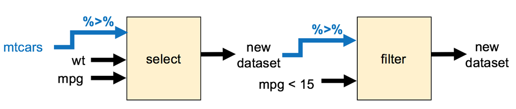

# How to write your own function

Each function in R has

- a name
- some arguments (input)
- some action
- return (output).

```r
function_name <- function(arguments){
    action
    return(output)
}
```

Input and output can be anything: list, plot, vector, etc.

# How to write your own function

Example: for given $x$ and $y$ compute $x^2+y^2$.

```r
sum_of_squares  <- function(x, y){
    result <- x^2 + y^2
    return(result)
}
```

- Name: `sum_of_squares`
- Input: a pair $x$ and $y$
- Output: $x^2+y^2$
- Action: compute `result` and return it

```r
sum_of_squares(x = 1, y = 10)
```

```
## [1] 101
```

```r
sum_of_squares(1, 10)
```

```
## [1] 101
```

# How to output multiple values

Output a list! Example: for given $x$, $y$ and $z$ compute min, max and mean

```r
min_max_mean  <- function(x, y, z){
    result <- list(min = min(x, y, z),
                   max = max(x, y, z),
                   mean = mean(x, y, z))
    return(result)
}
```

- Name: `min_max_mean`
- Input: a triple $x, y$ and $z$
- Output: a list with three elements containing min, max, mean
- Action: compute `result` and return it

```r
min_max_mean(1, 2, 3)
```

```
## $min
## [1] 1
##
## $max
## [1] 3
##
## $mean
## [1] 1
```

# Agenda for today

- Importing data with `readr`
- Factors

“Official” cheat sheet for `readr` available [here](https://www.rstudio.com/resources/cheatsheets/).

# Where does your data live?

- Data is stored in a **“file”**
  - e.g. `.txt` (text) or `.csv` (comma-separated values) file
- Files belong to a **“folder”/“directory”**
- Folders can be nested within other folders

# Filepath example (Mac)

- Application: Finder
- Default “root” directory: `/`

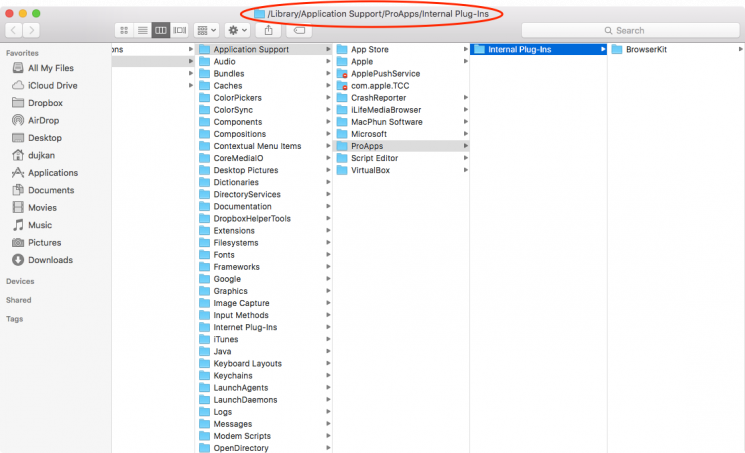

(Source: [iDB](https://www.idownloadblog.com/2015/12/07/how-to-full-file-path-mac-finder-window/))

# Filepath example (Windows)

- Application: File explorer
- Default “root” directory: `C:/`

[figure not shown]

(Source: [Computer Problem and solution](https://amitparashanker.wordpress.com/2016/03/30/how-to-recover-deleted-windows-10-program-files-after-an-update/))

# File paths

- A character string that tells you the location of a file
- **Absolute path:** starts from the “root” directory
  - e.g. `/Users/elenatuz/Downloads/datafile.csv`

# File paths

- A character string that tells you the location of a file
- **Absolute path:** starts from the “root” directory
  - e.g. `/Users/elenatuz/Downloads/datafile.csv`
- **Relative path:** starts from the current directory (denoted by `.`)
  - e.g. If I am in the folder `/Users/elenatuz`: `./Downloads/datafile.csv`
  - e.g. If I am in the folder `/Users/elenatuz/Downloads`: `./datafile.csv` or simply `datafile.csv`

# Working directories in R

- Directory where R looks for files that you ask it to load
- Also where R will put any files that you ask it to save
- You can see your current working directory at the top of the console or by typing `getwd()`

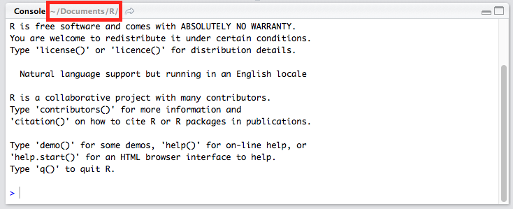

# How can I change my working directory in RStudio?

1. You can issue the command `setwd("<path of new directory>")`
2. In the menu bar, click Session > Set Working Directory, then click one of the options in the sub-menu

# Factors

- A concept unique to R
- Useful for working with categorical variables: variables that have a fixed and known set of possible values

# Why use factor variables instead of character variables?

**Reason 1:** Character variables don’t sort in a useful way

```r
x <- c("Dec", "Apr", "Jan", "Mar",
       "Mar", "Mar", "Apr", "Jan")
sort(x)
```

```
## [1] "Apr" "Apr" "Dec" "Jan" "Jan" "Mar" "Mar" "Mar"
```

# Why use factor variables instead of character variables?

**Reason 1:** Character variables don’t sort in a useful way

```r
x <- c("Dec", "Apr", "Jan", "Mar",
       "Mar", "Mar", "Apr", "Jan")
sort(x)
```

```
## [1] "Apr" "Apr" "Dec" "Jan" "Jan" "Mar" "Mar" "Mar"
```

**Reason 2:** Character variables don’t protect you from typos

```r
x <- c("Dec", "Apr", "Jam", "Mar",
       "Mar", "Mar", "Apr", "Jan")
```

# Why use factor variables instead of character variables?

**Reason 1:** Character variables don’t sort in a useful way

```r
x <- c("Dec", "Apr", "Jan", "Mar",
       "Mar", "Mar", "Apr", "Jan")
sort(x)
```

```
## [1] "Apr" "Apr" "Dec" "Jan" "Jan" "Mar" "Mar" "Mar"
```

**Reason 2:** Character variables don’t protect you from typos

```r
x <- c("Dec", "Apr", "Jam", "Mar",
       "Mar", "Mar", "Apr", "Jan")
```

Factor variables can fix both of these easily.

# How to convert a character variable to a factor variable?

- Use `factor()` (in base R) or `parse_factor()` (from the `readr` package)
- Give the function the list of valid categories, or **levels**

```r
month_levels <- c(
  "Jan", "Feb", "Mar", "Apr", "May", "Jun",
  "Jul", "Aug", "Sep", "Oct", "Nov", "Dec"
)
x <- c("Dec", "Apr", "Jam", "Mar",
       "Mar", "Mar", "Apr", "Jan")
```

# How to convert a character variable to a factor variable?

- Use `factor()` (in base R) or `parse_factor()` (from the `readr` package)
- Give the function the list of valid categories, or **levels**

```r
y1 <- factor(x, levels = month_levels)
y1
```

```
## [1] Dec  Apr  <NA> Mar  Mar  Mar  Apr  Jan
## Levels: Jan Feb Mar Apr May Jun Jul Aug Sep Oct Nov Dec
```

# How to convert a character variable to a factor variable?

- Use `factor()` (in base R) or `parse_factor()` (from the `readr` package)
- Give the function the list of valid categories, or **levels**

```r
y1 <- factor(x, levels = month_levels)
y1
```

```
## [1] Dec  Apr  <NA> Mar  Mar  Mar  Apr  Jan
## Levels: Jan Feb Mar Apr May Jun Jul Aug Sep Oct Nov Dec
```

```r
y2 <- parse_factor(x, levels = month_levels)
y2
```

```
## [1] Dec  Apr  <NA> Mar  Mar  Mar  Apr  Jan
## attr(,"problems")
## # A tibble: 1 x 4
##     row   col expected           actual
##   <int> <int> <chr>              <chr>
## 1     3    NA value in level set Jam
## Levels: Jan Feb Mar Apr May Jun Jul Aug Sep Oct Nov Dec
```

# How to convert a character variable to a factor variable?

- Use `factor()` (in base R) or `parse_factor()` (from the `readr` package)
- Give the function the list of valid categories, or **levels**

```r
sort(y1)
```

```
## [1] Jan Mar Mar Mar Apr Apr Dec
## Levels: Jan Feb Mar Apr May Jun Jul Aug Sep Oct Nov Dec
```

# Today’s dataset: NBA data

[figure not shown]

(Source: [Twitter](https://twitter.com/nbacom/status/745268087541403648))

**Optional material**

# Different packages for working with different data formats

- **.txt, .csv files (`readr`)**
- .xls, .xlsx files (`readxl`)
- SPSS, Stata & SAS files (`haven`)
- Databases (`DBI`)
- JSON files (`jsonlite`)
- XML files (`xml2`)
- Web APIs (`httr`)
- HTML web scraping (`rvest`)

# Factors under the hood

- Under the hood, the different levels of a factor are assigned numbers 1, 2, …
- The first level gets assigned the number 1, the next is 2, and so on

```r
y1
```

```
## [1] Dec  Apr  <NA> Mar  Mar  Mar  Apr  Jan
## Levels: Jan Feb Mar Apr May Jun Jul Aug Sep Oct Nov Dec
```

```r
str(y1)
```

```
##  Factor w/ 12 levels "Jan","Feb","Mar",..: 12 4 NA 3 3 3 4 1
```

# Ordered & unordered factors

- Factors can be ordered or unordered
- Example of ordered factor: T-shirt sizes (S < M < L)
- Example of unordered factor: ice-cream flavors
- R allows you to specify whether a factor should be ordered or not based on the `ordered` option in `factor()`
- Doesn’t matter which you use for the most part except when building models